# Loved or hated? An analysis of public dicourse around Jeremy Corbyn's Brexit strategy on Twitter.

### Check for missing values

```python
tweets.isnull().sum(axis = 0)
```

```
id                                0
created_at                        0
from_user_name                    0
from_user_id                      0
from_user_tweetcount              0
from_user_followercount           0
from_user_friendcount             0
location                     146868
in_reply_to_status_id        416992
retweets_total               445380
text_y                       331397
text                              0
negative                          0
positive                          0
neutral                           0
date                              0
pre_LC                            0
during_LC                         0
post_LC                           0
pre_CC                            0
during_CC                         0
post_CC                           0
time_period_labour                0
time_period_conservatives         0
is_retweet                        0
is_reply                          0
type                              0
overall_sent                      0
corbyn_mentioned                  0
johnson_mentioned                 0
mentions                          0
emotionality                      0
dtype: int64
```

As can be seen in the previous output, the variables "location", "in_reply_to_status_id", "retweets_total", and "text_y" (hashtags) have a lot of missing values. Since these missing values indicate that there was no data available (e.g. refer back to how I created the hashtags column), they are replaced by either a zero, or a string ("none"):

```python
tweets['retweets_total'] = tweets['retweets_total'].fillna(0)
```

```python
tweets['location'] = tweets['location'].fillna('none')
```

```python
tweets['text_y'] = tweets['text_y'].fillna('none')
```

```python
tweets['in_reply_to_status_id'] = tweets['in_reply_to_status_id'].fillna('none')
```

```python
tweets.isnull().sum(axis = 0)
```

```
id                           0
created_at                   0
from_user_name               0
from_user_id                 0
from_user_tweetcount         0
from_user_followercount      0
from_user_friendcount        0
location                     0
in_reply_to_status_id        0
retweets_total               0
text_y                       0
text                         0
negative                     0
positive                     0
neutral                      0
date                         0
pre_LC                       0
during_LC                    0
post_LC                      0
pre_CC                       0
during_CC                    0
post_CC                      0
time_period_labour           0
time_period_conservatives    0
is_retweet                   0
is_reply                     0
type                         0
overall_sent                 0
corbyn_mentioned             0
johnson_mentioned            0
mentions                     0
emotionality                 0
dtype: int64
```

```python
tweets.head()
```

|  | id | created_at | from_user_name | from_user_id | from_user_tweetcount | from_user_followercount | from_user_friendcount | location | in_reply_to_status_id | retweets_total | ... | time_period_labour | time_period_conservatives | is_retweet | is_reply | type | overall_sent | corbyn_mentioned | johnson_mentioned | mentions | emotionality |
| --- | --- | --- | --- | --- | --- | --- | --- | --- | --- | --- | --- | --- | --- | --- | --- | --- | --- | --- | --- | --- | --- |
| 1333981 | 1172847541601341441 | 2019-09-14 12:20:19 | hugh_canning | 2680706465 | 216414 | 4284 | 1189 | Hackney, Remoania 😈 | 1.17278e+18 | 0.0 | ... | not relevant | not relevant | 0 | 1 | reply | -2 | 0 | 0 | None | 4 |
| 3797122 | 1178795001733509120 | 2019-09-30 22:13:24 | patstokes | 21995533 | 47414 | 4954 | 1693 | Melbourne, Australia | none | 0.0 | ... | not relevant | during-CC | 1 | 0 | retweet | -1 | 0 | 0 | None | 3 |
| 242037 | 1171000573413462016 | 2019-09-09 10:01:07 | teragramytrehod | 106444283 | 3420 | 310 | 260 | London | none | 0.0 | ... | not relevant | not relevant | 1 | 0 | retweet | 1 | 0 | 0 | None | 3 |
| 3201741 | 1177405873326579712 | 2019-09-27 02:13:30 | pedroprola | 17173144 | 222324 | 9726 | 3811 | Lisboa, Portugal | none | 0.0 | ... | not relevant | pre-CC | 1 | 0 | retweet | -2 | 0 | 1 | Johnson | 4 |
| 3815235 | 1178891747272925184 | 2019-10-01 04:37:49 | Burke4Burke | 351857271 | 6972 | 232 | 688 | UK | none | 0.0 | ... | not relevant | during-CC | 1 | 0 | retweet | 0 | 0 | 1 | Johnson | 2 |

5 rows × 32 columns

### Looking for errors in the datset.

It might well be that some rows include wrong information. In the following, checks for all relevant variables are performed to ensure that this is not the case and that the ensuing analysis will not be corrupted.

```python
tweets['type'].value_counts()
```

```
retweet     356129
original     60865
reply        46695
Name: type, dtype: int64
```

```python
tweets['mentions'].value_counts()
```

```
None                402167
Johnson              45707
Corbyn               14184
Johnson & Corbyn      1631
Name: mentions, dtype: int64
```

```python
tweets['date'].value_counts().sort_index()
```

```
2019-09-09    31753
2019-09-10    19672
2019-09-11    20095
2019-09-12    22978
2019-09-13    16643
2019-09-14    14764
2019-09-15    14029
2019-09-16    16642
2019-09-17    14776
2019-09-18    16042
2019-09-19    13781
2019-09-20    11995
2019-09-21    10456
2019-09-22    11233
2019-09-23    15045
2019-09-24    20013
2019-09-25    17473
2019-09-26    16701
2019-09-27    13628
2019-09-28    15654
2019-09-29    15218
2019-09-30    16566
2019-10-01    14992
2019-10-02    18020
2019-10-03    20606
2019-10-04    15795
2019-10-05    14012
2019-10-06    15107
Name: date, dtype: int64
```

```python
tweets['overall_sent'].value_counts()
```

```
 0    166047
-1    115432
-2     66768
 1     65676
-3     26030
 2     17789
-4      3111
 3      2666
 4       170
Name: overall_sent, dtype: int64
```

```python
tweets['corbyn_mentioned'].value_counts()
```

```
0    447874
1     15815
Name: corbyn_mentioned, dtype: int64
```

```python
tweets['johnson_mentioned'].value_counts()
```

```
0    416351
1     47338
Name: johnson_mentioned, dtype: int64
```

```python
tweets['emotionality'].value_counts()
```

```
3     134698
2     120505
4     103723
5      65467
6      28464
7       9491
8       1191
9        148
10         2
Name: emotionality, dtype: int64
```

```python
tweets['location'].value_counts(ascending=False, sort=True)
```

```
none                              146873
United Kingdom                     12816
London                             12650
London, England                    11374
England, United Kingdom            10758
UK                                  9147
England                             3532
Scotland                            2613
South East, England                 2480
North West, England                 2102
Europe                              2045
Scotland, United Kingdom            2043
South West, England                 1985
London, UK                          1881
Manchester, England                 1677
Wales, United Kingdom               1578
Glasgow, Scotland                   1421
Ireland                             1354
Edinburgh, Scotland                 1347
North East, England                 1225
United States                       1181
European Union                      1127
West Midlands, England              1111
Liverpool, England                   954
Glasgow                              894
Manchester                           864
France                               856
Edinburgh                            851
Bristol, England                     808
East Midlands, England               798
                                   ...
Maryland lagos                         1
snowpoint city 🇩🇰                      1
ここではないどこか。                             1
Seaton, England                        1
Jervis Bay                             1
TEXAS!!!!!!                            1
Floating Around The Ethers             1
Either                                 1
Voerendaal                             1
Gab                                    1
All over                               1
Green Mountains                        1
Glasgow 1955                           1
A cottage in Oxfordshire               1
in .... Between                        1
London and Norfolk                     1
AR #TrumpArmy #Trumpville              1
Fleming Island, FL                     1
Deepcar                                1
Selby Yorkshire                        1
London | Essex                         1
Cambridge, UK / Sevilla, Spain         1
left of center                         1
lancaster,lancashire,uk                1
in a Sett somehere                     1
Crockenhill                            1
Şehitkamil, Gaziantep                  1
The Left Are The New Fascists          1
Bennetts field, AMEX, Brighton         1
arab world                             1
Name: location, Length: 40888, dtype: int64
```

```python
len(tweets)
```

```
463689
```

```python
tweets = tweets[tweets.location != 'United States']
```

```python
len(tweets)
```

```
462508
```

As can be seen in the reduced length of the dataframe, the removal seems to have worked. As a last check:

```python
tweets['location'].value_counts()
```

```
none                              146873
United Kingdom                     12816
London                             12650
London, England                    11374
England, United Kingdom            10758
UK                                  9147
England                             3532
Scotland                            2613
South East, England                 2480
North West, England                 2102
Europe                              2045
Scotland, United Kingdom            2043
South West, England                 1985
London, UK                          1881
Manchester, England                 1677
Wales, United Kingdom               1578
Glasgow, Scotland                   1421
Ireland                             1354
Edinburgh, Scotland                 1347
North East, England                 1225
European Union                      1127
West Midlands, England              1111
Liverpool, England                   954
Glasgow                              894
Manchester                           864
France                               856
Edinburgh                            851
Bristol, England                     808
East Midlands, England               798
Wales                                788
                                   ...
Maryland lagos                         1
snowpoint city 🇩🇰                      1
ここではないどこか。                             1
Seaton, England                        1
Jervis Bay                             1
TEXAS!!!!!!                            1
Floating Around The Ethers             1
Either                                 1
Voerendaal                             1
Gab                                    1
All over                               1
Green Mountains                        1
Glasgow 1955                           1
A cottage in Oxfordshire               1
in .... Between                        1
London and Norfolk                     1
AR #TrumpArmy #Trumpville              1
Fleming Island, FL                     1
Deepcar                                1
Selby Yorkshire                        1
London | Essex                         1
Cambridge, UK / Sevilla, Spain         1
left of center                         1
lancaster,lancashire,uk                1
in a Sett somehere                     1
Crockenhill                            1
Şehitkamil, Gaziantep                  1
The Left Are The New Fascists          1
Bennetts field, AMEX, Brighton         1
arab world                             1
Name: location, Length: 40887, dtype: int64
```

### Datatype transformations

In fact, most necessary transformations have already performed earlier. Nonetheless, here is a last check for whether or not all variables are currently in the appropriate datatype. For the ones that are not, transformations are performed.

```python
tweets.dtypes
```

```
id                                    int64
created_at                   datetime64[ns]
from_user_name                       object
from_user_id                          int64
from_user_tweetcount                  int64
from_user_followercount               int64
from_user_friendcount                 int64
location                             object
in_reply_to_status_id                object
retweets_total                      float64
text_y                               object
text                                 object
negative                              int64
positive                              int64
neutral                              object
date                                 object
pre_LC                                 bool
during_LC                              bool
post_LC                                bool
pre_CC                                 bool
during_CC                              bool
post_CC                                bool
time_period_labour                   object
time_period_conservatives            object
is_retweet                            int64
is_reply                              int64
type                                 object
overall_sent                          int64
corbyn_mentioned                      int64
johnson_mentioned                     int64
mentions                             object
emotionality                          int64
dtype: object
```

```python
tweets['neutral'] = tweets['neutral'].astype('int64')
```

```python
tweets['date'] = pd.to_datetime(tweets['date'])
```

```python
tweets.dtypes
```

```
id                                    int64
created_at                   datetime64[ns]
from_user_name                       object
from_user_id                          int64
from_user_tweetcount                  int64
from_user_followercount               int64
from_user_friendcount                 int64
location                             object
in_reply_to_status_id                object
retweets_total                      float64
text_y                               object
text                                 object
negative                              int64
positive                              int64
neutral                               int64
date                         datetime64[ns]
pre_LC                                 bool
during_LC                              bool
post_LC                                bool
pre_CC                                 bool
during_CC                              bool
post_CC                                bool
time_period_labour                   object
time_period_conservatives            object
is_retweet                            int64
is_reply                              int64
type                                 object
overall_sent                          int64
corbyn_mentioned                      int64
johnson_mentioned                     int64
mentions                             object
emotionality                          int64
dtype: object
```

As can be seen in this output, the transformations worked.

### Renaming several columns

For the following analysis, meaningful column names will be more helpful than, for example, the current column "text_y" that captures all hashtags that were included in a tweet, seperated by a comma. Hence, in the following some columns are renamed:

```python
tweets = tweets.rename(columns={"in_reply_to_status": "is_reply", "text_y": "hashtags", "negative": "negative_words", "positive": "positive_words", "neutral": "neutral_words"})
```

```python
tweets.columns
```

```
Index(['id', 'created_at', 'from_user_name', 'from_user_id',
       'from_user_tweetcount', 'from_user_followercount',
       'from_user_friendcount', 'location', 'in_reply_to_status_id',
       'retweets_total', 'hashtags', 'text', 'negative_words',
       'positive_words', 'neutral_words', 'date', 'pre_LC', 'during_LC',
       'post_LC', 'pre_CC', 'during_CC', 'post_CC', 'time_period_labour',
       'time_period_conservatives', 'is_retweet', 'is_reply', 'type',
       'overall_sent', 'corbyn_mentioned', 'johnson_mentioned', 'mentions',
       'emotionality'],
      dtype='object')
```

```python
len(tweets)
```

```
462508
```

Before moving on to the second dataset, it is necessary to create two subdatasets, namely one that includes only the tweets that mention Jeremy Corbyn and on ethat only includes tweets that mention Boris Johnson.

```python
tweets_cm = tweets.loc[tweets['corbyn_mentioned'] == 1]
len(tweets_cm)
```

```
15776
```

```python
tweets_jm = tweets.loc[tweets['johnson_mentioned'] == 1]
len(tweets_jm)
```

```
47159
```

*Note: It is of course very likely that both, Jeremy Corbyn and Boris Johnson will be referred to in different ways as well. However, it is hard to capture all of them in a comparable and balanced manner, and without including unrelated cases. Hence, I believe that the focus on their last names only should suffice to capture a comparable and valid dataset of a reasonable size.*

Having created an overall sentiment variable earlier that is now present in three different datasets (all tweets, tweets mentioning Jeremy Corbyn, and tweets mentioning Boris Johnson), it is now necessary to edit these datasets for a later visualisations, where date will be used as an index and sentiment as the dependent variable. No other variables are necessary for these variables, and therefore they will be left out.

```python
# Select the two relevant columns
tweetss_jm = tweets_jm[["date", "overall_sent"]]
# Aggregate sentiment by date
tweetss_jm = tweetss_jm.groupby(['date']).mean()
# Rename column for later merging
tweetss_jm = tweetss_jm.rename(columns={"overall_sent": "overall_sent_johnson"})
# Aggregate sentiment by date
tweetss_cm = tweets_cm[["date", "overall_sent"]]
# Aggregate sentiment by date
tweetss_cm = tweetss_cm.groupby(['date']).mean()
# Rename column for later merging
tweetss_cm = tweetss_cm.rename(columns={"overall_sent": "overall_sent_corbyn"})
# Select the two relevant columns
tweetss = tweets[["date", "overall_sent"]]
# Aggregate sentiment by date
tweetss = tweetss.groupby(['date']).mean()
```

Lastly, the three datasets are combined:

```python
evaluation = tweetss_cm.join(tweetss_jm)
```

```python
evaluation = evaluation.join(tweetss)
```

```python
evaluation
```

| date | overall_sent_corbyn | overall_sent_johnson | overall_sent |
| --- | --- | --- | --- |
| 2019-09-09 | -0.695493 | -0.653553 | -0.522032 |
| 2019-09-10 | 0.055690 | -0.502948 | -0.495044 |
| 2019-09-11 | -0.084291 | -0.304310 | -0.535233 |
| 2019-09-12 | 0.407252 | -0.589192 | -0.618877 |
| 2019-09-13 | 0.125758 | -0.632237 | -0.431576 |
| 2019-09-14 | -0.901149 | -0.995897 | -0.437835 |
| 2019-09-15 | -0.394191 | -0.565371 | -0.534192 |
| 2019-09-16 | -0.255255 | -0.517114 | -0.502018 |
| 2019-09-17 | -0.192478 | -0.447298 | -0.389654 |
| 2019-09-18 | -0.417330 | -0.664021 | -0.418332 |
| 2019-09-19 | -0.186788 | -0.514593 | -0.337695 |
| 2019-09-20 | -0.232472 | -0.334967 | -0.421589 |
| 2019-09-21 | -0.712803 | -0.670391 | -0.563183 |
| 2019-09-22 | -0.465479 | -0.559585 | -0.418265 |
| 2019-09-23 | -0.469919 | -0.022222 | -0.485779 |
| 2019-09-24 | -0.571227 | -0.575087 | -0.506812 |
| 2019-09-25 | -0.538642 | -0.886546 | -0.587338 |
| 2019-09-26 | -0.965385 | -1.059913 | -0.813156 |
| 2019-09-27 | -0.397059 | -0.879867 | -0.727774 |
| 2019-09-28 | -0.524476 | -0.617605 | -0.605719 |
| 2019-09-29 | -0.713846 | -0.563341 | -0.650122 |
| 2019-09-30 | -0.484305 | -0.894612 | -0.531745 |
| 2019-10-01 | -0.849821 | -0.404571 | -0.469285 |
| 2019-10-02 | -0.800350 | -0.294118 | -0.401336 |
| 2019-10-03 | -0.748466 | -0.361589 | -0.328614 |
| 2019-10-04 | -0.526316 | -0.230697 | -0.304304 |
| 2019-10-05 | -0.718447 | -0.938315 | -0.377682 |
| 2019-10-06 | -0.424552 | -0.530075 | -0.368177 |

As can be seen above, we now a dataset with date as the index, and the three daily aggregated sentiment values for each dataset. This will be useful later on for comparative visualisations.

### Checking variable distribution

In the following the distributions of key variables are checked. First, let's take a look at emotionality:

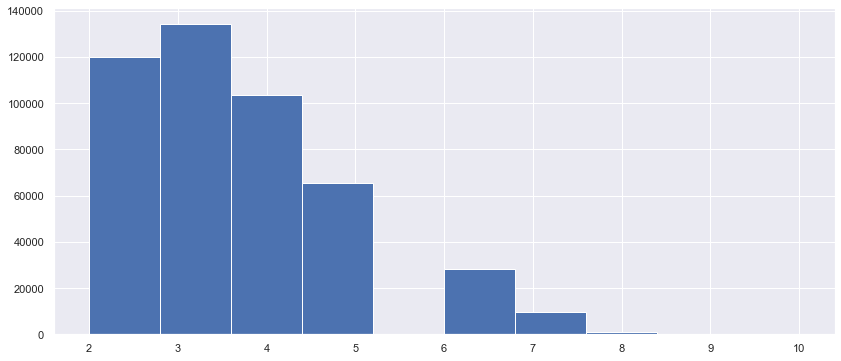

```python
tweets['emotionality'].hist(figsize=[14,6])
```

As can be seen, emotionality is not normally distributed. Luckily this is not a problem as this variable is only used in an explorative way to add context to the findings.

Next, let's investigate the distribution of overall sentiment per dataset:

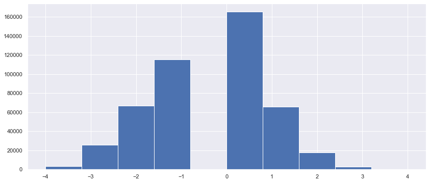

```python
tweets['overall_sent'].hist(figsize=[14,6])
```

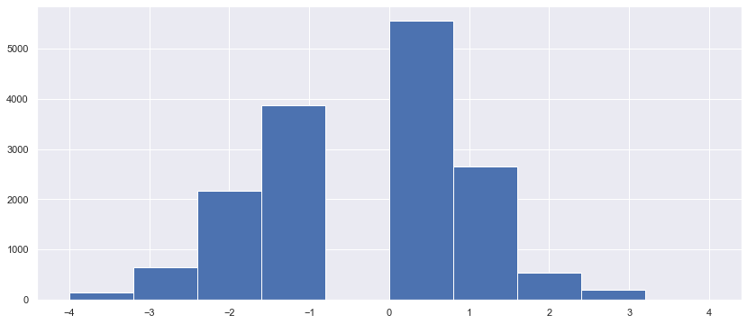

```python
tweets_cm['overall_sent'].hist(figsize=[14,6])
```

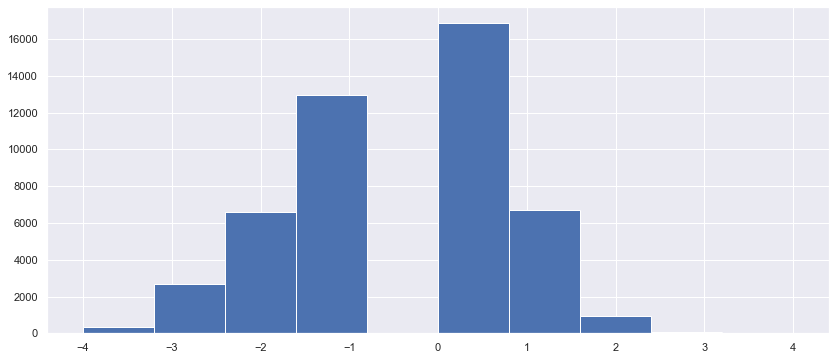

```python
tweets_jm['overall_sent'].hist(figsize=[14,6])
```

While slightly skewed towrds the negative side, this variable looks normally distributed and pretty much similar across all three datasets.

### Second data set

To test H2, it is necessary to include an additional dataset of the latest 3183 tweets made by Jeremy Corbyn's official account. Since not all of this data is necessary for the analysis being performed in this project, pre-selections and transformations are necessary, much like I just did for the tweets dataset.  
To begin, I inspect the dataset.

```python
tweets_c = pd.read_pickle("jeremycorbyn.pkl")
```

```python
tweets_c.head()
```

|  | contributors | coordinates | created_at | display_text_range | entities | extended_entities | favorite_count | favorited | full_text | geo | ... | quoted_status | quoted_status_id | quoted_status_id_str | quoted_status_permalink | retweet_count | retweeted | retweeted_status | source | truncated | user |
| --- | --- | --- | --- | --- | --- | --- | --- | --- | --- | --- | --- | --- | --- | --- | --- | --- | --- | --- | --- | --- | --- |
| 0 | None | None | Wed Oct 09 21:40:01 +0000 2019 | [0, 235] | {'hashtags': [], 'symbols': [], 'user_mentions... | NaN | 542 | False | We must continue to do everything we can to ro... | None | ... | NaN | NaN | NaN | NaN | 193 | False | NaN | <a href="https://mobile.twitter.com" rel="nofo... | False | {'id': 117777690, 'id_str': '117777690', 'name... |
| 1 | None | None | Wed Oct 09 17:41:02 +0000 2019 | [0, 256] | {'hashtags': [], 'symbols': [], 'user_mentions... | {'media': [{'id': 1181987940815245314, 'id_str... | 714 | False | A very productive meeting with UK representati... | None | ... | NaN | NaN | NaN | NaN | 239 | False | NaN | <a href="https://mobile.twitter.com" rel="nofo... | False | {'id': 117777690, 'id_str': '117777690', 'name... |
| 2 | None | None | Wed Oct 09 17:18:41 +0000 2019 | [0, 278] | {'hashtags': [], 'symbols': [], 'user_mentions... | NaN | 2737 | False | This is the type of high quality, eco-friendly... | None | ... | NaN | NaN | NaN | NaN | 895 | False | NaN | <a href="http://twitter.com/download/android" ... | False | {'id': 117777690, 'id_str': '117777690', 'name... |
| 3 | None | None | Wed Oct 09 17:08:57 +0000 2019 | [0, 246] | {'hashtags': [], 'symbols': [], 'user_mentions... | NaN | 8113 | False | I am deeply concerned at the actions of the Tu... | None | ... | NaN | NaN | NaN | NaN | 2402 | False | NaN | <a href="https://mobile.twitter.com" rel="nofo... | False | {'id': 117777690, 'id_str': '117777690', 'name... |
| 4 | None | None | Wed Oct 09 15:06:00 +0000 2019 | [0, 114] | {'hashtags': [], 'symbols': [], 'user_mentions... | {'media': [{'id': 1181925351729061895, 'id_str... | 586 | False | This is what Labour Roots is all about.\n\nJoi... | None | ... | NaN | NaN | NaN | NaN | 282 | False | NaN | <a href="https://studio.twitter.com" rel="nofo... | False | {'id': 117777690, 'id_str': '117777690', 'name... |

5 rows × 31 columns

```python
len(tweets_c)
```

```
3183
```

```python
tweets_c.dtypes
```

```
contributors                  object
coordinates                   object
created_at                    object
display_text_range            object
entities                      object
extended_entities             object
favorite_count                 int64
favorited                       bool
full_text                     object
geo                           object
id                             int64
id_str                        object
in_reply_to_screen_name       object
in_reply_to_status_id        float64
in_reply_to_status_id_str     object
in_reply_to_user_id          float64
in_reply_to_user_id_str       object
is_quote_status                 bool
lang                          object
place                         object
possibly_sensitive            object
quoted_status                 object
quoted_status_id             float64
quoted_status_id_str          object
quoted_status_permalink       object
retweet_count                  int64
retweeted                       bool
retweeted_status              object
source                        object
truncated                       bool
user                          object
dtype: object
```

After this initial inspection, several necessary steps are performed.  
Step 1: Select only the relevant columns

```python
tweets_c = tweets_c[["created_at", "full_text", "display_text_range", "retweet_count"]]
```

```python
tweets_c.columns
```

```
Index(['created_at', 'full_text', 'display_text_range', 'retweet_count'], dtype='object')
```

Step 2: Transform datatypes  
The initial transformation:

```python
tweets_c['created_at'] = pd.to_datetime(tweets_c['created_at'])
```

Removing time zones:

```python
tweets_c['created_at'] = tweets_c['created_at'].dt.tz_localize(None)
```

```python
tweets_c.head()
```

|  | created_at | full_text | display_text_range | retweet_count |
| --- | --- | --- | --- | --- |
| 0 | 2019-10-09 21:40:01 | We must continue to do everything we can to ro... | [0, 235] | 193 |
| 1 | 2019-10-09 17:41:02 | A very productive meeting with UK representati... | [0, 256] | 239 |
| 2 | 2019-10-09 17:18:41 | This is the type of high quality, eco-friendly... | [0, 278] | 895 |
| 3 | 2019-10-09 17:08:57 | I am deeply concerned at the actions of the Tu... | [0, 246] | 2402 |
| 4 | 2019-10-09 15:06:00 | This is what Labour Roots is all about.\n\nJoi... | [0, 114] | 282 |

```python
tweets_c.dtypes
```

```
created_at            datetime64[ns]
full_text                     object
display_text_range            object
retweet_count                  int64
dtype: object
```

Step 3: Select only tweets from the relevant time frame (incl. one day lag).

```python
mask2 = (tweets_c['created_at'] > '2019-09-08') & (tweets_c['created_at'] <= '2019-10-07')
```

```python
tweets_c = tweets_c.loc[mask2]
```

```python
tweets_c.head()
```

|  | created_at | full_text | display_text_range | retweet_count |
| --- | --- | --- | --- | --- |
| 20 | 2019-10-06 22:22:13 | Congratulations to @antoniocostapm and the Por... | [0, 218] | 1239 |
| 21 | 2019-10-06 18:45:50 | For once the Daily Mail is right.\n\nWe'll tak... | [0, 262] | 3147 |
| 22 | 2019-10-06 12:04:36 | RT @LabourSJ: Labour is the only party serious... | [0, 120] | 643 |
| 23 | 2019-10-06 09:56:29 | The deal being proposed by Boris Johnson will ... | [0, 121] | 1456 |
| 24 | 2019-10-06 09:02:35 | Football is part of our lives, our community a... | [0, 239] | 1902 |

```python
tweets_c.tail()
```

|  | created_at | full_text | display_text_range | retweet_count |
| --- | --- | --- | --- | --- |
| 57 | 2019-09-08 12:16:00 | Anna has lived here for 55 years, after arrivi... | [0, 207] | 4656 |
| 58 | 2019-09-08 11:07:31 | We need to stop No Deal and those in Number 10... | [0, 97] | 1562 |
| 59 | 2019-09-08 10:29:11 | I'm proud we named our initiative to ensure mo... | [0, 268] | 883 |
| 60 | 2019-09-08 10:11:08 | RT @johnmcdonnellMP: Labour wants a General El... | [0, 119] | 1742 |
| 61 | 2019-09-08 06:59:00 | We're ready. Are you?\n\nRegister to vote toda... | [0, 84] | 4351 |

```python
len(tweets_c)
```

```
241
```

Step 4: Checking for missing values

```python
tweets_c.isnull().sum(axis = 0)
```

```
created_at            0
full_text             0
display_text_range    0
retweet_count         0
dtype: int64
```

As can be seen in the output above, the dataset tweets_c includes a total of 241 tweets from Jeremy Corbyn' official acount, has four columns and doesn't include any missing values.

## Data Exploration & Evaluation

In the following section, the data will be explored. This includes exploratory visualisations that either can answer the RQs or provide relevant context to the interpretation of the final analysis. Furthermore, bivariate relationships of key variables will be explored (e.g. the development of sentiment over time).

### Overall tweets dataset

To begin, overall trends in the tweets dataset are visualised. While not all of those tweets will be included in the later analyses, understanding overall trends in the data is important to contextualise later findings. First, let's take a look at how the overall tweet sentiment developed over time:

```python
tweetss
```

| date | overall_sent |
| --- | --- |
| 2019-09-09 | -0.522032 |
| 2019-09-10 | -0.495044 |
| 2019-09-11 | -0.535233 |
| 2019-09-12 | -0.618877 |
| 2019-09-13 | -0.431576 |
| 2019-09-14 | -0.437835 |
| 2019-09-15 | -0.534192 |
| 2019-09-16 | -0.502018 |
| 2019-09-17 | -0.389654 |
| 2019-09-18 | -0.418332 |
| 2019-09-19 | -0.337695 |
| 2019-09-20 | -0.421589 |
| 2019-09-21 | -0.563183 |
| 2019-09-22 | -0.418265 |
| 2019-09-23 | -0.485779 |
| 2019-09-24 | -0.506812 |
| 2019-09-25 | -0.587338 |
| 2019-09-26 | -0.813156 |
| 2019-09-27 | -0.727774 |
| 2019-09-28 | -0.605719 |
| 2019-09-29 | -0.650122 |
| 2019-09-30 | -0.531745 |
| 2019-10-01 | -0.469285 |
| 2019-10-02 | -0.401336 |
| 2019-10-03 | -0.328614 |
| 2019-10-04 | -0.304304 |
| 2019-10-05 | -0.377682 |
| 2019-10-06 | -0.368177 |

```python
sns.set(rc={'figure.figsize':(15, 5)})
```

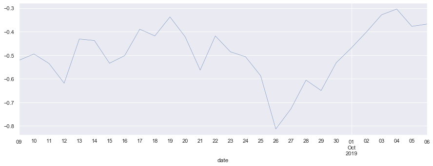

```python
tweetss['overall_sent'].plot(linewidth=0.5);
```

This visualisation displays the overall sentiment per day over time for all Brexit tweets. It shows that the overall sentiment is always negative, however, there appear to be quite some fluctuations over time. The sentiment remains comparably stable up until the labour party conference, after which it rapidly decreases. The lowest point is reached pretty much exactly between the two conferences (on the 26th of September to be precise), after which the sentiment becomes more positive again. The highest value is reached on the 4th of October, shortly after the conservative party conference came to an end.

```python
tweets['overall_sent'].describe().transpose()
```

```
count    462508.000000
mean         -0.495269
std           1.243061
min          -4.000000
25%          -1.000000
50%           0.000000
75%           0.000000
max           4.000000
Name: overall_sent, dtype: float64
```

Descriptive Summary:  
On average, tweet sentiment is rather negative (*M*= - 0.50, *SD*= 1.24). While the average hides extremes on both the positive and the negative end, the visualisation discussed earlier goes to show that the overall daily sentiment never becomes positive and that about half of the days are actually below the mean, with uptakes only in early September and early October. This suggests an overall rather negative public Twitter discourse on Brexit.

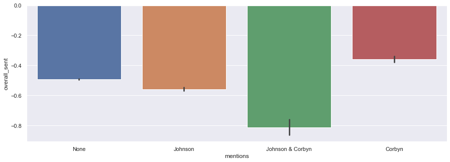

```python
sns.barplot(x='mentions', y='overall_sent', data=tweets)
```

Adding to the overall sentiment trend displayed earlier, this visualisation shows the overall sentiment per mentions-category. It shows that on average, Brexit-tweets that are mentioning only Jeremy Corbyn are the least negative, with tweets mentioning none being the second, and tweets mentioning Boris Johnson the third least negative out of the four. The Brexit-tweets that mentioned both party leaders appear to be by far the most negative ones on average.

To add to our understanding of the data, in the following emotionality will be explored.

```python
tweetss2 = tweets[["date", "emotionality"]]
```

```python
tweetss2 = tweetss2.groupby(['date']).mean()
```

```python
tweetss2
```

| date | emotionality |
| --- | --- |
| 2019-09-09 | 3.464419 |
| 2019-09-10 | 3.626137 |
| 2019-09-11 | 3.512476 |
| 2019-09-12 | 3.529768 |
| 2019-09-13 | 3.487074 |
| 2019-09-14 | 3.620968 |
| 2019-09-15 | 3.565951 |
| 2019-09-16 | 3.415095 |
| 2019-09-17 | 3.494271 |
| 2019-09-18 | 3.478147 |
| 2019-09-19 | 3.460923 |
| 2019-09-20 | 3.410644 |
| 2019-09-21 | 3.588878 |
| 2019-09-22 | 3.378578 |
| 2019-09-23 | 3.419103 |
| 2019-09-24 | 3.612692 |
| 2019-09-25 | 3.721528 |
| 2019-09-26 | 3.868502 |
| 2019-09-27 | 3.763586 |
| 2019-09-28 | 3.605272 |
| 2019-09-29 | 3.642552 |
| 2019-09-30 | 3.509856 |
| 2019-10-01 | 3.421373 |
| 2019-10-02 | 3.348441 |
| 2019-10-03 | 3.437260 |
| 2019-10-04 | 3.285732 |
| 2019-10-05 | 3.492418 |
| 2019-10-06 | 3.626252 |

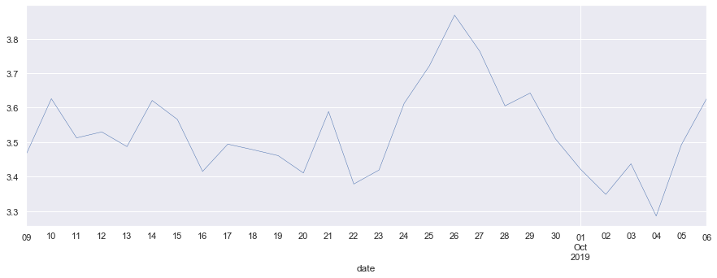

```python
tweetss2['emotionality'].plot(linewidth=0.5);
```

```python
tweets['emotionality'].describe().transpose()
```

```
count    462508.000000
mean          3.527489
std           1.313953
min           2.000000
25%           2.000000
50%           3.000000
75%           4.000000
max          10.000000
Name: emotionality, dtype: float64
```

The exploration of sentiment earlier might hide some trends, as strongly positive and strongly negative tweets can cancel each other out. The visualisation above thus displays how emotionality (basically sentiment transformed onto a purely positive scale; *M*= 3.53, *SD*= 1.31) develops over time for the complete set of tweets. It shows that the time period between the two party conferences (23th to 29th of September) was by far the most emotional one. Before this period, there were only comparably minor fluctuations. After this time period, the emotionality of tweets drops to its lowest point witin the sampling period (4th of Oct.), before rising above average again on the 6th of October. Overall, this indicates that especially the time between the party conferences was a period of heated debate on Twitter.

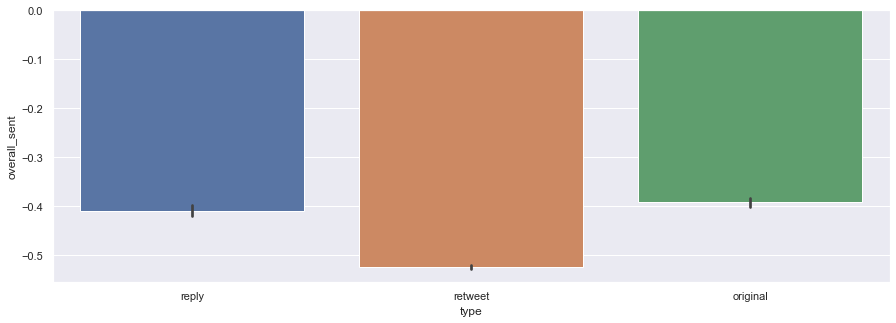

```python
sns.barplot(x='type', y='overall_sent', data=tweets)
```

This visualisation shows that original tweets are, on average, the least negative (although replies hardly differ). Retweets instead appear to be more negative on average. This indicates that while the type of a tweet seems to matter somewhat, the overall difference in sentiment is not particularly large. Hence, the type of a tweet (which arguably might have made quite a difference) will not be included in the following analyses.

### Tweets mentioning Jeremy Corbyn

After having explored general trends in the data, it is now time to look at the specific tweet set that will be used for later hypothesis testing. Namely, the dataset that only includes Brexit tweets mentioning Jeremy Corbyn.

```python
tweets_cm['overall_sent'].describe().transpose()
```

```
count    15776.000000
mean        -0.404285
std          1.249874
min         -4.000000
25%         -1.000000
50%          0.000000
75%          0.000000
max          4.000000
Name: overall_sent, dtype: float64
```

```python
tweets_cm['johnson_mentioned'].describe().transpose()
```

```
count    15776.000000
mean         0.103131
std          0.304140
min          0.000000
25%          0.000000
50%          0.000000
75%          0.000000
max          1.000000
Name: johnson_mentioned, dtype: float64
```

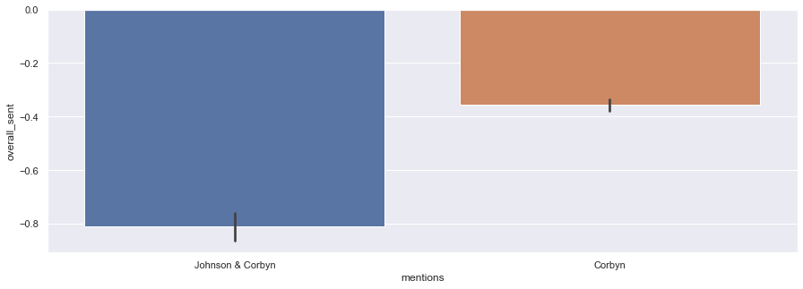

```python
sns.barplot(x='mentions', y='overall_sent', data=tweets_cm)
```

This table reports several descriptive statistics for the "overall_sentiment" and "johnson_mentioned" variables in the dataset that consists only of the Brexit-Tweets that mention Jeremy Corbyn. The dataset consists of a total of 15776 tweets, which have a rather strongly negative sentiment on avergae (*M*= -0.40, *SD*= 1.25). As can be seen in the following visualisation, the negative sentiment is more strongly pronounced among the tweets that mention both Jeremy Corbyn and Boris Johnson than it is among tweets that only mention Jeremy Corbyn. However, it is important to note that the former only constitute about 10% of the sample (see table).

```python
tweetss_cm
```

| date | overall_sent_corbyn |
| --- | --- |
| 2019-09-09 | -0.695493 |
| 2019-09-10 | 0.055690 |
| 2019-09-11 | -0.084291 |
| 2019-09-12 | 0.407252 |
| 2019-09-13 | 0.125758 |
| 2019-09-14 | -0.901149 |
| 2019-09-15 | -0.394191 |
| 2019-09-16 | -0.255255 |
| 2019-09-17 | -0.192478 |
| 2019-09-18 | -0.417330 |
| 2019-09-19 | -0.186788 |
| 2019-09-20 | -0.232472 |
| 2019-09-21 | -0.712803 |
| 2019-09-22 | -0.465479 |
| 2019-09-23 | -0.469919 |
| 2019-09-24 | -0.571227 |
| 2019-09-25 | -0.538642 |
| 2019-09-26 | -0.965385 |
| 2019-09-27 | -0.397059 |
| 2019-09-28 | -0.524476 |
| 2019-09-29 | -0.713846 |
| 2019-09-30 | -0.484305 |
| 2019-10-01 | -0.849821 |
| 2019-10-02 | -0.800350 |
| 2019-10-03 | -0.748466 |
| 2019-10-04 | -0.526316 |
| 2019-10-05 | -0.718447 |
| 2019-10-06 | -0.424552 |

```python
sns.set(rc={'figure.figsize':(15, 5)})
```

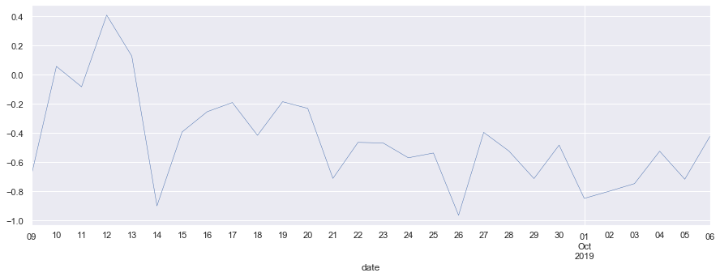

```python
tweetss_cm['overall_sent_corbyn'].plot(linewidth=0.5);
```

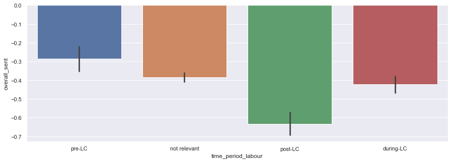

```python
sns.barplot(x='time_period_labour', y='overall_sent', data=tweets_cm)
```

This visualisation covers the time periods before, during, and after the Labur party conference and displays the overall tweet sentiment during these time periods for Brexit tweets that mentioned Jeremy Corbyn. H1a expected that the labour party conference would improve overall sentiment towards Jeremy Corbyn's Brexit strategy. However, this visualisation suggests the opposite, with tweets being least negative before the conference had started and most negative after it finished. Whether or not these relationships between tweet sentiment and time periods are statistically significant will be tested later on.

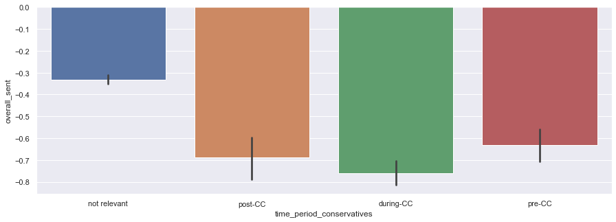

```python
sns.barplot(x='time_period_conservatives', y='overall_sent', data=tweets_cm)
```

This visualisation covers the time periods before, during, and after the Conservatives party conference and displays the overall tweet sentiment during these time periods for Brexittweets that mentioned Jeremy Corbyn. H1a expected that the conservative party conference would decrease overall sentiment towards Jeremy Corbyn's Brexit strategy. Based on this visualisation, this does indeed appear to be the case, although the negative effects are more pronounced during the conference than afterwards. Whether or not these relationships between tweet sentiment and time periods are statistically significant will be tested later on.

In a next step, the most frequent hashtags are examined.

```python
tweets_cm.columns
```

```
Index(['id', 'created_at', 'from_user_name', 'from_user_id',
       'from_user_tweetcount', 'from_user_followercount',
       'from_user_friendcount', 'location', 'in_reply_to_status_id',
       'retweets_total', 'hashtags', 'text', 'negative_words',
       'positive_words', 'neutral_words', 'date', 'pre_LC', 'during_LC',
       'post_LC', 'pre_CC', 'during_CC', 'post_CC', 'time_period_labour',
       'time_period_conservatives', 'is_retweet', 'is_reply', 'type',
       'overall_sent', 'corbyn_mentioned', 'johnson_mentioned', 'mentions',
       'emotionality'],
      dtype='object')
```

```python
texts = tweets_cm['hashtags'].values.tolist()
```

```python
total_words = Counter()
for text in texts:
    # making text lower case
    text = text.lower()
    # removing URLS
    text = text.split(',')
    newtext = []
    for item in text:
        if 'http' not in item:
            newtext.append(item)

    newtext = ' '.join(newtext)

    # splitting the text in words (tokens)
    tokens = re.findall(r"[\w']+|[.,!?;$@]", newtext)
    for token in tokens:
        total_words[token] += 1
```

```python
total_words.most_common(25)
```

```
[('none', 10897),
 ('brexit', 1418),
 ('surrenderbill', 607),
 ('leaveoct31st', 603),
 ('leaveoct31', 577),
 ('corbyn', 396),
 ('stopbrexit', 290),
 ('remain', 245),
 ('ldconf', 233),
 ('labour', 233),
 ('igoforjo', 223),
 ('lab19', 200),
 ('brexitalliance', 169),
 ('peoplesvote', 158),
 ('libdems', 149),
 ('brexitparty', 127),
 ('jc4pm', 123),
 ('labourconference2019', 102),
 ('resignjoswinson', 100),
 ('marr', 95),
 ('r4today', 91),
 ('joswinsonisatory', 84),
 ('labourparty', 67),
 ('eu', 66),
 ('borisjohnson', 62)]
```

This output is interesting in so far, as two of the most popular hashtags among all Brexit tweets that mentioned Jeremy Corbyn are related to the leave campaing (#leaveoct31st, #leaveoct31). This points towards quite a few people tweeting about Jeremy Corbyn that might advocate for a Brexit by all means (although it is hard to tell whether this really is the case without reading the whole tweet)

## Modeling and Hypothesis Testing

In the following, the three hypotheses posed earlier will be tested.

### Testing H1a and H1b

This is done through an ANOVA conducted in SPSS. To conduct it, it is first necessary to export the relevant dataset into a format that SPSS can read:

```python
tweets_cm.columns
```

```
Index(['id', 'created_at', 'from_user_name', 'from_user_id',
       'from_user_tweetcount', 'from_user_followercount',
       'from_user_friendcount', 'location', 'in_reply_to_status_id',
       'retweets_total', 'hashtags', 'text', 'negative_words',
       'positive_words', 'neutral_words', 'date', 'pre_LC', 'during_LC',
       'post_LC', 'pre_CC', 'during_CC', 'post_CC', 'time_period_labour',
       'time_period_conservatives', 'is_retweet', 'is_reply', 'type',
       'overall_sent', 'corbyn_mentioned', 'johnson_mentioned', 'mentions',
       'emotionality'],
      dtype='object')
```

Selecting relevant columns only:

```python
tweets_cm_anova = tweets_cm[["id", "overall_sent", "time_period_labour", "time_period_conservatives"]]
```

Transforming strings into numeric values:

```python
mymap = {'not relevant':1, 'pre-LC':2, 'during-LC':3, 'post-LC':4, 'pre-CC':2, 'during-CC':3, 'post-CC':4}
```

```python
tweets_cm_anova = tweets_cm_anova.applymap(lambda s: mymap.get(s) if s in mymap else s)
```

```python
tweets_cm_anova.head()
```

|  | id | overall_sent | time_period_labour | time_period_conservatives |
| --- | --- | --- | --- | --- |
| 1616604 | 1173574423867211782 | -1 | 2 | 1 |
| 4456082 | 1180172951053832198 | -1 | 1 | 4 |
| 1179196 | 1172492818662641664 | -1 | 1 | 1 |
| 3624263 | 1178420011670605825 | -2 | 1 | 3 |
| 2858659 | 1176672290525892609 | 1 | 4 | 2 |

Exporting the datafile:

```python
tweets_cm_anova.to_csv('tweets_cm_anova.csv')
```

### H1a - SPSS output

In the following, the SPSS output for a one way ANOVA with three different time periods (pre_LC, during-LC, post-LC) as the independent, and overall tweet sentiment as the dependent variable:  
*Note that not relevant tweets were not considered for the analyses*

[figure not shown]

### H1b - SPSS output

In the following, the SPSS output for a one way ANOVA with three different time periods (pre_CC, during-CC, post-CC) as the independent, and overall tweet sentiment as the dependent variable:

[figure not shown]

As can be seen in the output displayed above, there was a significant effect of time_period on overall sentiment at the p<.05 level for the three conditions [F(2 ,3076,8) = 3,30, p= .037].  
Since the Levene's test turned out significant [F(2, 3076)= 35.29, p< .001], equal variances can not be assumed. Therefore, a post hoc comparison was performed using the Games-Howell test, as this one does not assume equal variances. The test showed that the pre-CC condition was signifiantly higher (M = - .63, SD= 1.19) than the during-LC (M = -.76, SD= 1.06) (p= .024), but not significantly higher than the post-LC condition (M = -.69, SD= 1.37); p= .645. The difference between the post_LC (M = -.69, SD= 1.37)and the during-LC condition (M = -.76, SD= 1.06) was also not significant; p = .398. Therefore, H1b is only partly supported as the tweet sentiment did indeed decrease after the conservative party conference started, but as this trend did not significantly change for the worse after the conference was over.

## Testing H2: Time Series

H2 assumed that Jeremy Corbyn's Twitter activity is causally related to his evaluation in such a way that increased activity leads to a better evaluation of him. This will be tested by means of a time series analysis in the following. Time series analyses are especially useful to test agenda-setting effects (Russell Neumann, et al., 2014), as they allow researchers to examine how one variable affects another one over time and infer causality. Since H2 is inspired by agenda-setting effects and does indeed examine whether Jeremy Corbyn's tweet frequency on a given day affects tweet sentiment on the following day, time series is the optimal method to test this hypothesis.

```python
tweetss_cm
```

| date | overall_sent_corbyn |
| --- | --- |
| 2019-09-09 | -0.695493 |
| 2019-09-10 | 0.055690 |
| 2019-09-11 | -0.084291 |
| 2019-09-12 | 0.407252 |
| 2019-09-13 | 0.125758 |
| 2019-09-14 | -0.901149 |
| 2019-09-15 | -0.394191 |
| 2019-09-16 | -0.255255 |
| 2019-09-17 | -0.192478 |
| 2019-09-18 | -0.417330 |
| 2019-09-19 | -0.186788 |
| 2019-09-20 | -0.232472 |
| 2019-09-21 | -0.712803 |
| 2019-09-22 | -0.465479 |
| 2019-09-23 | -0.469919 |
| 2019-09-24 | -0.571227 |
| 2019-09-25 | -0.538642 |
| 2019-09-26 | -0.965385 |
| 2019-09-27 | -0.397059 |
| 2019-09-28 | -0.524476 |
| 2019-09-29 | -0.713846 |
| 2019-09-30 | -0.484305 |
| 2019-10-01 | -0.849821 |
| 2019-10-02 | -0.800350 |
| 2019-10-03 | -0.748466 |
| 2019-10-04 | -0.526316 |
| 2019-10-05 | -0.718447 |
| 2019-10-06 | -0.424552 |

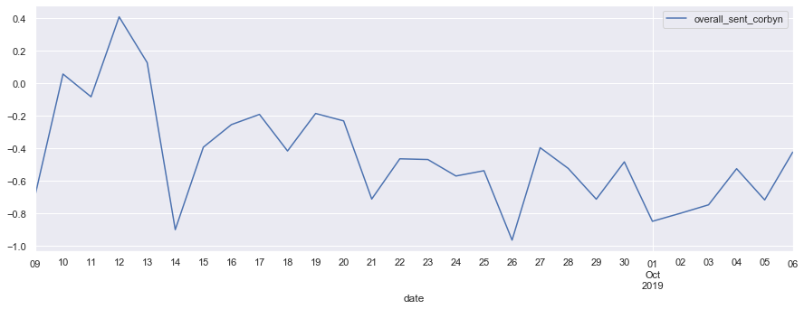

```python
tweetss_cm[['overall_sent_corbyn']].plot() # plot
```

```python
tweets_c
```

|  | created_at | full_text | display_text_range | retweet_count |
| --- | --- | --- | --- | --- |
| 20 | 2019-10-06 22:22:13 | Congratulations to @antoniocostapm and the Por... | [0, 218] | 1239 |
| 21 | 2019-10-06 18:45:50 | For once the Daily Mail is right.\n\nWe'll tak... | [0, 262] | 3147 |
| 22 | 2019-10-06 12:04:36 | RT @LabourSJ: Labour is the only party serious... | [0, 120] | 643 |
| 23 | 2019-10-06 09:56:29 | The deal being proposed by Boris Johnson will ... | [0, 121] | 1456 |
| 24 | 2019-10-06 09:02:35 | Football is part of our lives, our community a... | [0, 239] | 1902 |
| 25 | 2019-10-06 08:46:08 | RT @MarshadeCordova: Staff at @BurgerKing refu... | [0, 140] | 593 |
| 26 | 2019-10-06 08:04:29 | The only people who won’t suffer from Boris Jo... | [0, 143] | 2864 |
| 27 | 2019-10-05 19:26:52 | We're in Newcastle, coming together, united an... | [0, 127] | 1013 |
| 28 | 2019-10-05 18:42:22 | We're gearing up for a General Election.\n\nJo... | [0, 96] | 3121 |
| 29 | 2019-10-05 16:41:47 | RT @strawfie: Jeremy Corbyn took the #Strawfie... | [0, 140] | 265 |
| 30 | 2019-10-05 16:27:42 | RT @strawfie: Jeremy Corbyn took the #Strawfie... | [0, 139] | 90 |
| 31 | 2019-10-05 13:56:27 | Great to be campaigning in North East Derbyshi... | [0, 275] | 627 |
| 32 | 2019-10-05 13:55:53 | RT @Guatemalagirl: I'd never done the #strawfi... | [0, 140] | 383 |
| 33 | 2019-10-05 13:55:40 | RT @strawfie: Thank you @JeremyCorbyn for such... | [0, 139] | 344 |
| 34 | 2019-10-05 11:25:50 | Imagine being Christina and knowing the NHS ca... | [0, 153] | 3218 |
| 35 | 2019-10-05 08:50:47 | They're trying to cover this up and it's a com... | [0, 280] | 4601 |
| 36 | 2019-10-05 06:39:15 | RT @GreenpeaceUK: Yesterday Brazilian Environm... | [0, 140] | 623 |
| 37 | 2019-10-04 14:40:21 | Today we remember The Battle of Cable Street a... | [0, 144] | 4085 |
| 38 | 2019-10-04 14:40:11 | RT @RichardBurgon: Absolutely heartbreaking. P... | [0, 139] | 570 |
| 39 | 2019-10-04 12:17:32 | RT @LabourSJ: My old boss Mo Mowlam would be a... | [0, 140] | 1757 |
| 40 | 2019-10-04 10:39:29 | Rory Stewart wholeheartedly backed Tory cuts t... | [0, 186] | 3397 |
| 41 | 2019-10-04 10:38:40 | RT @MayorofLondon: At The Battle of Cable Stre... | [0, 140] | 802 |
| 42 | 2019-10-04 07:49:13 | Homelessness only becomes inevitable when a go... | [0, 280] | 3137 |
| 43 | 2019-10-03 18:29:23 | RT @UKLabour: This #BlackHistoryMonth we celeb... | [0, 140] | 445 |
| 44 | 2019-10-03 17:43:36 | The only people who won’t suffer from Boris Jo... | [0, 129] | 4335 |
| 45 | 2019-10-03 16:42:16 | RT @IanLaveryMP: Today, I officially launched ... | [0, 140] | 399 |
| 46 | 2019-10-03 16:18:02 | RT @HackneyAbbott: As it is #TBT and also #Bla... | [0, 140] | 1542 |
| 47 | 2019-10-03 09:55:58 | Last night, @DinaAsherSmith became the first B... | [0, 181] | 1062 |
| 48 | 2019-10-02 19:59:51 | Sending @BernieSanders my very best wishes. Ho... | [0, 131] | 5069 |
| 49 | 2019-10-02 19:58:56 | "First they ignore you, then they laugh at you... | [0, 279] | 1536 |
| ... | ... | ... | ... | ... |
| 32 | 2019-09-12 08:08:18 | The domestic abuse bill cannot be allowed to f... | [0, 272] | 1348 |
| 33 | 2019-09-11 20:33:48 | Official government documents confirm Boris Jo... | [0, 178] | 5480 |
| 34 | 2019-09-11 15:38:00 | Netanyahu can’t just decide to make a third of... | [0, 245] | 10607 |
| 35 | 2019-09-11 15:15:24 | Boris Johnson is not above the law.\n\nhttps:/... | [0, 60] | 2992 |
| 36 | 2019-09-11 07:59:50 | I visited Norwich - a city that is seeing its ... | [0, 72] | 1678 |
| 37 | 2019-09-10 20:06:15 | Today I met these inspiring health workers. Th... | [0, 238] | 919 |
| 38 | 2019-09-10 18:58:09 | Today I met courageous Harland and Wolff worke... | [0, 278] | 671 |
| 39 | 2019-09-10 18:07:29 | RT @maryonthegreen: Mary #Wollstonecraft died ... | [0, 140] | 838 |
| 40 | 2019-09-10 17:10:17 | Here's the advice the BBC neglects to tell you... | [0, 103] | 3043 |
| 41 | 2019-09-10 14:54:11 | RT @IanLaveryMP: Earlier today from the #TUC20... | [0, 140] | 492 |
| 42 | 2019-09-10 14:54:07 | RT @TWT_NOW: It’s been a busy few weeks and th... | [0, 140] | 189 |
| 43 | 2019-09-10 13:59:19 | We’re going after the tax avoiders. \n\nWe’re ... | [0, 213] | 10939 |
| 44 | 2019-09-10 13:55:08 | RT @UKLabour: JUST ANNOUNCED: A Labour Governm... | [0, 140] | 2126 |
| 45 | 2019-09-10 13:52:14 | RT @DawnButlerBrent: Boris Johnson should resc... | [0, 140] | 1160 |
| 46 | 2019-09-10 12:43:26 | In the next few weeks, the establishment will ... | [0, 145] | 3719 |
| 47 | 2019-09-10 10:58:00 | RT @LabourByTheMany: Join @johnmcdonnellMP @Yo... | [0, 140] | 173 |
| 48 | 2019-09-10 10:30:54 | Change is coming. \n\nAnd it must be change th... | [0, 264] | 3895 |
| 49 | 2019-09-10 09:42:26 | RT @robdelaney: Parliament is locked out but t... | [0, 140] | 826 |
| 50 | 2019-09-10 08:00:40 | A No Deal Brexit wouldn’t affect Boris Johnson... | [0, 137] | 2072 |
| 51 | 2019-09-10 06:01:00 | I want to turf out Boris Johnson's reckless go... | [0, 55] | 4214 |
| 52 | 2019-09-09 21:09:47 | RT @JonAshworth: Jacob Rees Mogg's attack on a... | [0, 144] | 719 |
| 53 | 2019-09-09 18:24:49 | RT @DawnButlerBrent: Donald Trump recently des... | [0, 140] | 3571 |
| 54 | 2019-09-09 14:28:57 | The Prime Minister's decision to shut down par... | [0, 75] | 3227 |
| 55 | 2019-09-08 20:02:31 | I will visit these workers at any time.\n\nWil... | [0, 75] | 1587 |
| 56 | 2019-09-08 15:00:51 | RT @PeoplesMomentum: Definitely don't register... | [0, 110] | 1374 |
| 57 | 2019-09-08 12:16:00 | Anna has lived here for 55 years, after arrivi... | [0, 207] | 4656 |
| 58 | 2019-09-08 11:07:31 | We need to stop No Deal and those in Number 10... | [0, 97] | 1562 |
| 59 | 2019-09-08 10:29:11 | I'm proud we named our initiative to ensure mo... | [0, 268] | 883 |
| 60 | 2019-09-08 10:11:08 | RT @johnmcdonnellMP: Labour wants a General El... | [0, 119] | 1742 |
| 61 | 2019-09-08 06:59:00 | We're ready. Are you?\n\nRegister to vote toda... | [0, 84] | 4351 |

241 rows × 4 columns

```python
tweets_c.dtypes
```

```
created_at            datetime64[ns]
full_text                     object
display_text_range            object
retweet_count                  int64
dtype: object
```

```python
tweets_c['date'] = tweets_c['created_at'].dt.date
```

```python
tweets_c['date1'] = tweets_c['created_at'].dt.date
```

```python
tweets_c.index=pd.DatetimeIndex(tweets_c['date'])
```

```python
tweets_c
```

| date | created_at | full_text | display_text_range | retweet_count | date | date1 |
| --- | --- | --- | --- | --- | --- | --- |
| 2019-10-06 | 2019-10-06 22:22:13 | Congratulations to @antoniocostapm and the Por... | [0, 218] | 1239 | 2019-10-06 | 2019-10-06 |
| 2019-10-06 | 2019-10-06 18:45:50 | For once the Daily Mail is right.\n\nWe'll tak... | [0, 262] | 3147 | 2019-10-06 | 2019-10-06 |
| 2019-10-06 | 2019-10-06 12:04:36 | RT @LabourSJ: Labour is the only party serious... | [0, 120] | 643 | 2019-10-06 | 2019-10-06 |
| 2019-10-06 | 2019-10-06 09:56:29 | The deal being proposed by Boris Johnson will ... | [0, 121] | 1456 | 2019-10-06 | 2019-10-06 |
| 2019-10-06 | 2019-10-06 09:02:35 | Football is part of our lives, our community a... | [0, 239] | 1902 | 2019-10-06 | 2019-10-06 |
| 2019-10-06 | 2019-10-06 08:46:08 | RT @MarshadeCordova: Staff at @BurgerKing refu... | [0, 140] | 593 | 2019-10-06 | 2019-10-06 |
| 2019-10-06 | 2019-10-06 08:04:29 | The only people who won’t suffer from Boris Jo... | [0, 143] | 2864 | 2019-10-06 | 2019-10-06 |
| 2019-10-05 | 2019-10-05 19:26:52 | We're in Newcastle, coming together, united an... | [0, 127] | 1013 | 2019-10-05 | 2019-10-05 |
| 2019-10-05 | 2019-10-05 18:42:22 | We're gearing up for a General Election.\n\nJo... | [0, 96] | 3121 | 2019-10-05 | 2019-10-05 |
| 2019-10-05 | 2019-10-05 16:41:47 | RT @strawfie: Jeremy Corbyn took the #Strawfie... | [0, 140] | 265 | 2019-10-05 | 2019-10-05 |
| 2019-10-05 | 2019-10-05 16:27:42 | RT @strawfie: Jeremy Corbyn took the #Strawfie... | [0, 139] | 90 | 2019-10-05 | 2019-10-05 |
| 2019-10-05 | 2019-10-05 13:56:27 | Great to be campaigning in North East Derbyshi... | [0, 275] | 627 | 2019-10-05 | 2019-10-05 |
| 2019-10-05 | 2019-10-05 13:55:53 | RT @Guatemalagirl: I'd never done the #strawfi... | [0, 140] | 383 | 2019-10-05 | 2019-10-05 |
| 2019-10-05 | 2019-10-05 13:55:40 | RT @strawfie: Thank you @JeremyCorbyn for such... | [0, 139] | 344 | 2019-10-05 | 2019-10-05 |
| 2019-10-05 | 2019-10-05 11:25:50 | Imagine being Christina and knowing the NHS ca... | [0, 153] | 3218 | 2019-10-05 | 2019-10-05 |
| 2019-10-05 | 2019-10-05 08:50:47 | They're trying to cover this up and it's a com... | [0, 280] | 4601 | 2019-10-05 | 2019-10-05 |
| 2019-10-05 | 2019-10-05 06:39:15 | RT @GreenpeaceUK: Yesterday Brazilian Environm... | [0, 140] | 623 | 2019-10-05 | 2019-10-05 |
| 2019-10-04 | 2019-10-04 14:40:21 | Today we remember The Battle of Cable Street a... | [0, 144] | 4085 | 2019-10-04 | 2019-10-04 |
| 2019-10-04 | 2019-10-04 14:40:11 | RT @RichardBurgon: Absolutely heartbreaking. P... | [0, 139] | 570 | 2019-10-04 | 2019-10-04 |
| 2019-10-04 | 2019-10-04 12:17:32 | RT @LabourSJ: My old boss Mo Mowlam would be a... | [0, 140] | 1757 | 2019-10-04 | 2019-10-04 |
| 2019-10-04 | 2019-10-04 10:39:29 | Rory Stewart wholeheartedly backed Tory cuts t... | [0, 186] | 3397 | 2019-10-04 | 2019-10-04 |
| 2019-10-04 | 2019-10-04 10:38:40 | RT @MayorofLondon: At The Battle of Cable Stre... | [0, 140] | 802 | 2019-10-04 | 2019-10-04 |
| 2019-10-04 | 2019-10-04 07:49:13 | Homelessness only becomes inevitable when a go... | [0, 280] | 3137 | 2019-10-04 | 2019-10-04 |
| 2019-10-03 | 2019-10-03 18:29:23 | RT @UKLabour: This #BlackHistoryMonth we celeb... | [0, 140] | 445 | 2019-10-03 | 2019-10-03 |
| 2019-10-03 | 2019-10-03 17:43:36 | The only people who won’t suffer from Boris Jo... | [0, 129] | 4335 | 2019-10-03 | 2019-10-03 |
| 2019-10-03 | 2019-10-03 16:42:16 | RT @IanLaveryMP: Today, I officially launched ... | [0, 140] | 399 | 2019-10-03 | 2019-10-03 |
| 2019-10-03 | 2019-10-03 16:18:02 | RT @HackneyAbbott: As it is #TBT and also #Bla... | [0, 140] | 1542 | 2019-10-03 | 2019-10-03 |
| 2019-10-03 | 2019-10-03 09:55:58 | Last night, @DinaAsherSmith became the first B... | [0, 181] | 1062 | 2019-10-03 | 2019-10-03 |
| 2019-10-02 | 2019-10-02 19:59:51 | Sending @BernieSanders my very best wishes. Ho... | [0, 131] | 5069 | 2019-10-02 | 2019-10-02 |
| 2019-10-02 | 2019-10-02 19:58:56 | "First they ignore you, then they laugh at you... | [0, 279] | 1536 | 2019-10-02 | 2019-10-02 |
| ... | ... | ... | ... | ... | ... | ... |
| 2019-09-12 | 2019-09-12 08:08:18 | The domestic abuse bill cannot be allowed to f... | [0, 272] | 1348 | 2019-09-12 | 2019-09-12 |
| 2019-09-11 | 2019-09-11 20:33:48 | Official government documents confirm Boris Jo... | [0, 178] | 5480 | 2019-09-11 | 2019-09-11 |
| 2019-09-11 | 2019-09-11 15:38:00 | Netanyahu can’t just decide to make a third of... | [0, 245] | 10607 | 2019-09-11 | 2019-09-11 |
| 2019-09-11 | 2019-09-11 15:15:24 | Boris Johnson is not above the law.\n\nhttps:/... | [0, 60] | 2992 | 2019-09-11 | 2019-09-11 |
| 2019-09-11 | 2019-09-11 07:59:50 | I visited Norwich - a city that is seeing its ... | [0, 72] | 1678 | 2019-09-11 | 2019-09-11 |
| 2019-09-10 | 2019-09-10 20:06:15 | Today I met these inspiring health workers. Th... | [0, 238] | 919 | 2019-09-10 | 2019-09-10 |
| 2019-09-10 | 2019-09-10 18:58:09 | Today I met courageous Harland and Wolff worke... | [0, 278] | 671 | 2019-09-10 | 2019-09-10 |
| 2019-09-10 | 2019-09-10 18:07:29 | RT @maryonthegreen: Mary #Wollstonecraft died ... | [0, 140] | 838 | 2019-09-10 | 2019-09-10 |
| 2019-09-10 | 2019-09-10 17:10:17 | Here's the advice the BBC neglects to tell you... | [0, 103] | 3043 | 2019-09-10 | 2019-09-10 |
| 2019-09-10 | 2019-09-10 14:54:11 | RT @IanLaveryMP: Earlier today from the #TUC20... | [0, 140] | 492 | 2019-09-10 | 2019-09-10 |
| 2019-09-10 | 2019-09-10 14:54:07 | RT @TWT_NOW: It’s been a busy few weeks and th... | [0, 140] | 189 | 2019-09-10 | 2019-09-10 |
| 2019-09-10 | 2019-09-10 13:59:19 | We’re going after the tax avoiders. \n\nWe’re ... | [0, 213] | 10939 | 2019-09-10 | 2019-09-10 |
| 2019-09-10 | 2019-09-10 13:55:08 | RT @UKLabour: JUST ANNOUNCED: A Labour Governm... | [0, 140] | 2126 | 2019-09-10 | 2019-09-10 |
| 2019-09-10 | 2019-09-10 13:52:14 | RT @DawnButlerBrent: Boris Johnson should resc... | [0, 140] | 1160 | 2019-09-10 | 2019-09-10 |
| 2019-09-10 | 2019-09-10 12:43:26 | In the next few weeks, the establishment will ... | [0, 145] | 3719 | 2019-09-10 | 2019-09-10 |
| 2019-09-10 | 2019-09-10 10:58:00 | RT @LabourByTheMany: Join @johnmcdonnellMP @Yo... | [0, 140] | 173 | 2019-09-10 | 2019-09-10 |
| 2019-09-10 | 2019-09-10 10:30:54 | Change is coming. \n\nAnd it must be change th... | [0, 264] | 3895 | 2019-09-10 | 2019-09-10 |
| 2019-09-10 | 2019-09-10 09:42:26 | RT @robdelaney: Parliament is locked out but t... | [0, 140] | 826 | 2019-09-10 | 2019-09-10 |
| 2019-09-10 | 2019-09-10 08:00:40 | A No Deal Brexit wouldn’t affect Boris Johnson... | [0, 137] | 2072 | 2019-09-10 | 2019-09-10 |
| 2019-09-10 | 2019-09-10 06:01:00 | I want to turf out Boris Johnson's reckless go... | [0, 55] | 4214 | 2019-09-10 | 2019-09-10 |
| 2019-09-09 | 2019-09-09 21:09:47 | RT @JonAshworth: Jacob Rees Mogg's attack on a... | [0, 144] | 719 | 2019-09-09 | 2019-09-09 |
| 2019-09-09 | 2019-09-09 18:24:49 | RT @DawnButlerBrent: Donald Trump recently des... | [0, 140] | 3571 | 2019-09-09 | 2019-09-09 |
| 2019-09-09 | 2019-09-09 14:28:57 | The Prime Minister's decision to shut down par... | [0, 75] | 3227 | 2019-09-09 | 2019-09-09 |
| 2019-09-08 | 2019-09-08 20:02:31 | I will visit these workers at any time.\n\nWil... | [0, 75] | 1587 | 2019-09-08 | 2019-09-08 |
| 2019-09-08 | 2019-09-08 15:00:51 | RT @PeoplesMomentum: Definitely don't register... | [0, 110] | 1374 | 2019-09-08 | 2019-09-08 |
| 2019-09-08 | 2019-09-08 12:16:00 | Anna has lived here for 55 years, after arrivi... | [0, 207] | 4656 | 2019-09-08 | 2019-09-08 |
| 2019-09-08 | 2019-09-08 11:07:31 | We need to stop No Deal and those in Number 10... | [0, 97] | 1562 | 2019-09-08 | 2019-09-08 |
| 2019-09-08 | 2019-09-08 10:29:11 | I'm proud we named our initiative to ensure mo... | [0, 268] | 883 | 2019-09-08 | 2019-09-08 |
| 2019-09-08 | 2019-09-08 10:11:08 | RT @johnmcdonnellMP: Labour wants a General El... | [0, 119] | 1742 | 2019-09-08 | 2019-09-08 |
| 2019-09-08 | 2019-09-08 06:59:00 | We're ready. Are you?\n\nRegister to vote toda... | [0, 84] | 4351 | 2019-09-08 | 2019-09-08 |

241 rows × 6 columns

```python
tweets_c2 = tweets_c.groupby(['date1']).size()
```

```python
tweets_c2.head()
```

```
date1
2019-09-08     7
2019-09-09     3
2019-09-10    15
2019-09-11     4
2019-09-12     7
dtype: int64
```

```python
tweets_c2 = pd.DataFrame(data=tweets_c2, columns=['no_of_tweets'])
```

```python
ts_data = tweetss_cm.join(pd.DataFrame(tweets_c2),how='left').fillna(0)
```

```python
ts_data
```

| date | overall_sent_corbyn | no_of_tweets |
| --- | --- | --- |
| 2019-09-09 | -0.695493 | 3 |
| 2019-09-10 | 0.055690 | 15 |
| 2019-09-11 | -0.084291 | 4 |
| 2019-09-12 | 0.407252 | 7 |
| 2019-09-13 | 0.125758 | 7 |
| 2019-09-14 | -0.901149 | 6 |
| 2019-09-15 | -0.394191 | 3 |
| 2019-09-16 | -0.255255 | 3 |
| 2019-09-17 | -0.192478 | 4 |
| 2019-09-18 | -0.417330 | 9 |
| 2019-09-19 | -0.186788 | 14 |
| 2019-09-20 | -0.232472 | 11 |
| 2019-09-21 | -0.712803 | 17 |
| 2019-09-22 | -0.465479 | 12 |
| 2019-09-23 | -0.469919 | 7 |
| 2019-09-24 | -0.571227 | 15 |
| 2019-09-25 | -0.538642 | 12 |
| 2019-09-26 | -0.965385 | 5 |
| 2019-09-27 | -0.397059 | 5 |
| 2019-09-28 | -0.524476 | 7 |
| 2019-09-29 | -0.713846 | 12 |
| 2019-09-30 | -0.484305 | 8 |
| 2019-10-01 | -0.849821 | 7 |
| 2019-10-02 | -0.800350 | 13 |
| 2019-10-03 | -0.748466 | 5 |
| 2019-10-04 | -0.526316 | 6 |
| 2019-10-05 | -0.718447 | 10 |
| 2019-10-06 | -0.424552 | 7 |

### Stationarity

```python
sm.tsa.stattools.adfuller(ts_data['overall_sent_corbyn'])
```

```
(-3.4753062645831228,
 0.008644396693764128,
 0,
 27,
 {'1%': -3.6996079738860943,
  '5%': -2.9764303469999494,
  '10%': -2.627601001371742},
 -2.9408960377955324)
```

```python
sm.tsa.stattools.adfuller(ts_data['no_of_tweets'])
```

```
(-2.0530644240804907,
 0.2638013332404884,
 7,
 20,
 {'1%': -3.8092091249999998, '5%': -3.0216450000000004, '10%': -2.6507125},
 99.57494343284368)
```

With a p-value below .05, the 'overall_sent' series appears to be stationary. The series for 'no_of_tweets' however is not. Thus, we need to difference. To do so, a new dataframe is created:

```python
ts_data_diff=ts_data
ts_data_diff['overall_sent_corbyn']=ts_data_diff['overall_sent_corbyn'].diff()
ts_data_diff['no_of_tweets']=ts_data_diff['no_of_tweets'].diff()
```

```python
ts_data_diff.head()
```

| date | overall_sent_corbyn | no_of_tweets |
| --- | --- | --- |
| 2019-09-09 | NaN | NaN |
| 2019-09-10 | 0.751183 | 12.0 |
| 2019-09-11 | -0.139981 | -11.0 |
| 2019-09-12 | 0.491544 | 3.0 |
| 2019-09-13 | -0.281495 | 0.0 |

```python
sm.tsa.stattools.adfuller(ts_data_diff.ix[1:]['overall_sent_corbyn'])
```

```
(-5.379267823026181,
 3.7439021344043733e-06,
 1,
 25,
 {'1%': -3.7238633119999998, '5%': -2.98648896, '10%': -2.6328004},
 -0.23337515066671344)
```

```python
sm.tsa.stattools.adfuller(ts_data_diff.ix[1:]['no_of_tweets'])
```

```
(-5.958213038723407,
 2.0688015182447384e-07,
 1,
 25,
 {'1%': -3.7238633119999998, '5%': -2.98648896, '10%': -2.6328004},
 97.86593885030004)
```

As can be seen in the output abve, both variables are now stationary.

In the following a VAR model is estimated. The first line in the dataset is left out, as it contains NaN after the differencing. For simplicity, only one lag is used. However, this also might make some sense, as tweets are usually unlikely to have long-lasting effects.

```python
dfsub = ts_data_diff.ix[1:][['overall_sent_corbyn','no_of_tweets']]
model = sm.tsa.VAR(dfsub)
results = model.fit(1)
results.summary()
```

```
  Summary of Regression Results
==================================
Model:                         VAR
Method:                        OLS
Date:           Sun, 20, Oct, 2019
Time:                     16:06:53
--------------------------------------------------------------------
No. of Equations:         2.00000    BIC:                    1.28828
Nobs:                     26.0000    HQIC:                   1.08155
Log likelihood:          -80.7581    FPE:                    2.71832
AIC:                     0.997948    Det(Omega_mle):         2.18500
--------------------------------------------------------------------
Results for equation overall_sent_corbyn
=========================================================================================
                            coefficient       std. error           t-stat            prob
-----------------------------------------------------------------------------------------
const                         -0.017669         0.065864           -0.268           0.788
L1.overall_sent_corbyn        -0.329526         0.181672           -1.814           0.070
L1.no_of_tweets               -0.004059         0.012697           -0.320           0.749
=========================================================================================

Results for equation no_of_tweets
=========================================================================================
                            coefficient       std. error           t-stat            prob
-----------------------------------------------------------------------------------------
const                         -0.202454         0.878037           -0.231           0.818
L1.overall_sent_corbyn        -0.837603         2.421884           -0.346           0.729
L1.no_of_tweets               -0.393631         0.169269           -2.325           0.020
=========================================================================================

Correlation matrix of residuals
                       overall_sent_corbyn  no_of_tweets
overall_sent_corbyn               1.000000     -0.168000
no_of_tweets                     -0.168000      1.000000
```

```python
print(results.test_causality('overall_sent_corbyn',['no_of_tweets']))
```

```
<statsmodels.tsa.vector_ar.hypothesis_test_results.CausalityTestResults object. H_0: no_of_tweets does not Granger-cause overall_sent_corbyn: fail to reject at 5% significance level. Test statistic: 0.102, critical value: 4.052>, p-value: 0.751>
```

```python
print(results.test_causality('no_of_tweets',['no_of_tweets']))
```

```
<statsmodels.tsa.vector_ar.hypothesis_test_results.CausalityTestResults object. H_0: no_of_tweets does not Granger-cause no_of_tweets: reject at 5% significance level. Test statistic: 5.408, critical value: 4.052>, p-value: 0.025>
```

Based on the output, as well as the causality tests, H2 has to be rejected. Increased Twitter activity by Jeremy Corbyn does not cause any changes in sentiment. Neither do changes in sentiment affect Jeremy Corbyn's tweeting frequency. The only aspect that does seem to predict Jeremy Corbyn's tweet frequency is the number of tweets that his official account published the previous day.

in the following, these effects will be visualised (note that only the number of tweets effect on the number of tweets was significant).

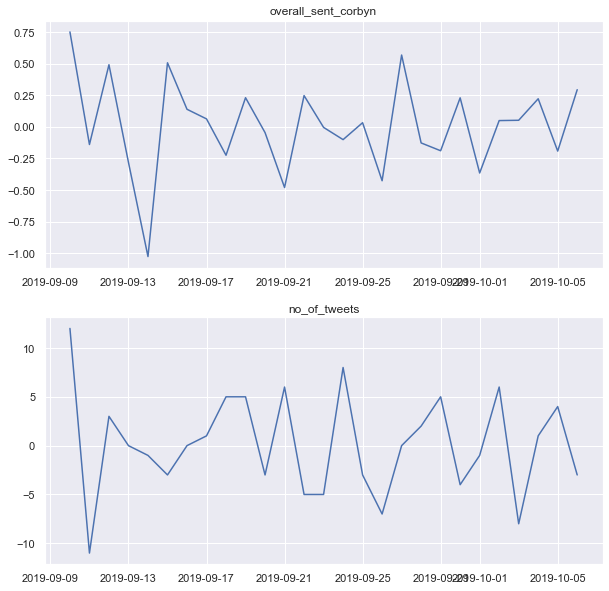

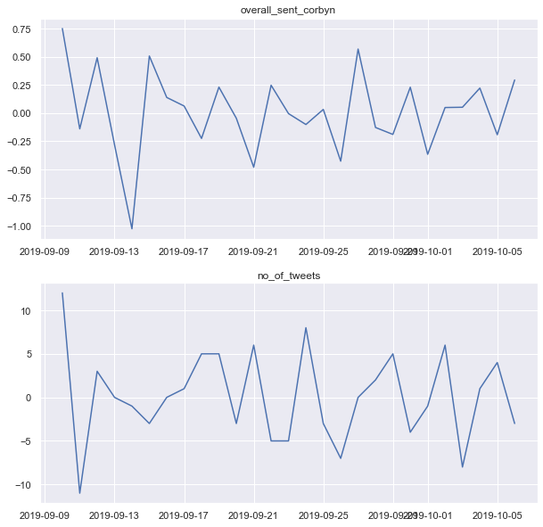

```python
results.plot()
```

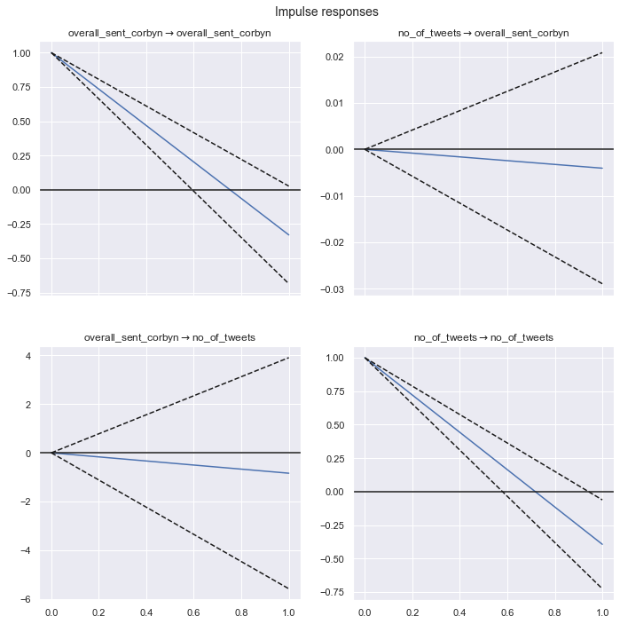

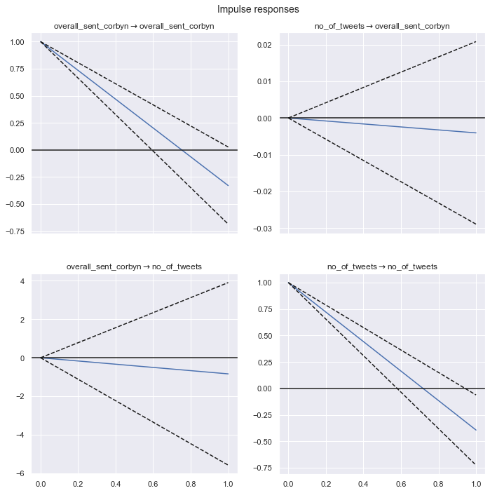

```python
irf = results.irf(1)
irf.plot()
```

Next, I compute the *forecast error variance* (FEV), which is a good indicator to show how much of the movement of one variable is attributed by shocks of its own past and to what extent by shocks of the other variables. The method can show how much variation of one variable can be explained by its own past or by another variable.

```python
fevd = results.fevd(1)
fevd.summary()
```

```
FEVD for overall_sent_corbyn
     overall_sent_corbyn  no_of_tweets
0               1.000000      0.000000

FEVD for no_of_tweets
     overall_sent_corbyn  no_of_tweets
0               0.028224      0.971776
```

The results of the FEV indicate that after one day, 2.8% of variation in the number of tweets can be explained by the overall sentiment. However, remember that this effect was not significant.

To ensure that the constructed VAR model is robust several tests need to be conducted. The first test is the Portmonteau (Q) test. Its null hypothesis assumes the residuals to be white noise, meaning that there is no autocorrelation in the time series. If autocorrelation is present in the data, that means that the time series is highly correlated with a lagged version of itself.  
The comand "results.residuals" returns residuals values needed in robustness checks and is used for the following tests. Note that the first number of the next two outputs contains the test statistics, and the second number the p value.

```python
sm.stats.diagnostic.acorr_ljungbox(results.resid['no_of_tweets'],lags=1)
```

```
(array([0.02179224]), array([0.88264113]))
```

```python
sm.stats.diagnostic.acorr_ljungbox(results.resid['overall_sent_corbyn'],lags=1)
```

```
(array([0.71613745]), array([0.39741383]))
```

The tests for autocorrelation indicate that residuals morror white noise (at 1st lang, no_of_tweets: 0.02, ns; overall_sent: 0.72, ns).

Next, the data is checked for heteroscedasticity. This is done by performing the Portmonteau (Q) test again, but now by looking at the squared residuals of the series.

```python
sres_no_of_tweets=[]
```

```python
for line in results.resid['no_of_tweets']:
    r_s=line*line
    sres_no_of_tweets.append(r_s)
```

```python
sm.stats.diagnostic.acorr_ljungbox(sres_no_of_tweets,lags=1)
```

```
(array([1.25246764]), array([0.26308169]))
```

```python
sres_overall_sent=[]
for line in results.resid['overall_sent_corbyn']:
    r_s=line*line
    #print(r_s)
    sres_overall_sent.append(r_s)
```

```python
sm.stats.diagnostic.acorr_ljungbox(sres_overall_sent,lags=1)
```

```
(array([0.33594645]), array([0.5621784]))
```

The final test - the VAR stability test - checks the eigenvalue stability condition after estimating the VAR model. The modulus of each eigenvalue has to be less than 1 so that the VAR model can be considered stable. If the VAR model is considered stable, we can interpret the CIRF and FEVD as outlined above.

```python
smtsa.vector_ar.var_model.VARProcess.is_stable(results)
```

```
True
```

### Testing H3: Linear regression

In order to not only access whether Jeremy Corbyn's tweeting frequency matters, but also to provide helpful insights for which features might improve his reach (as measured in retweets), H3 examines whether a tweets' emotionality and overall sentiment predict its number of retweets.  
This hypothesis is tested by means of a linear regression with retweets_total as the continuous dependent variable and emotionality and overall sentiment as the features/continuous independent variables. The code for the OLS model was taken from the "Liner Regression" notebook on the Digital Analytics github page.

```python
#Create a list of features (IV's)
features = ['emotionality', 'overall_sent']
```

```python
# Define the model
OLS_model = sm.OLS(tweets['retweets_total'], sm.add_constant(tweets[features]))
```

```python
# Get the results
result = OLS_model.fit()
```

```python
# Print the results
print(result.summary())
```

```
                            OLS Regression Results
==============================================================================
Dep. Variable:         retweets_total   R-squared:                       0.000
Model:                            OLS   Adj. R-squared:                 -0.000
Method:                 Least Squares   F-statistic:                    0.3135
Date:                Sun, 20 Oct 2019   Prob (F-statistic):              0.731
Time:                        16:06:56   Log-Likelihood:            -2.0613e+06
No. Observations:              462508   AIC:                         4.123e+06
Df Residuals:                  462505   BIC:                         4.123e+06
Df Model:                           2
Covariance Type:            nonrobust
================================================================================
                   coef    std err          t      P>|t|      [0.025      0.975]
--------------------------------------------------------------------------------
const            0.5144      0.090      5.738      0.000       0.339       0.690
emotionality     0.0182      0.025      0.729      0.466      -0.031       0.067
overall_sent    -0.0009      0.026     -0.034      0.973      -0.053       0.051
==============================================================================
Omnibus:                  1964215.447   Durbin-Watson:                   2.001
Prob(Omnibus):                  0.000   Jarque-Bera (JB):    9959602570898.510
Skew:                         124.012   Prob(JB):                         0.00
Kurtosis:                   22735.183   Cond. No.                         11.9
==============================================================================

Warnings:
[1] Standard Errors assume that the covariance matrix of the errors is correctly specified.
```

Contrary to the expectation, neither the emotionality of a tweet (*b* = 0.018, *p* = .466), nor its overall sentiment (*b*= - .001, *p* = .973) signiicantly predicted the number of retweets. H3 thus needs to be rejected, indicating that reach is not necessarily dependent on how emotional or positive/negative a tweet is. Overall the model explained 0% of the variane in the dependent variable.

## Evaluation

In the following, the results of the hypothesis testing are interpreted. To do so, let's visualise overall sentiment over time for a) all tweets, b) tweets mentioning Jeremy Corbyn, and c) tweets mentioning Boris Johnson.

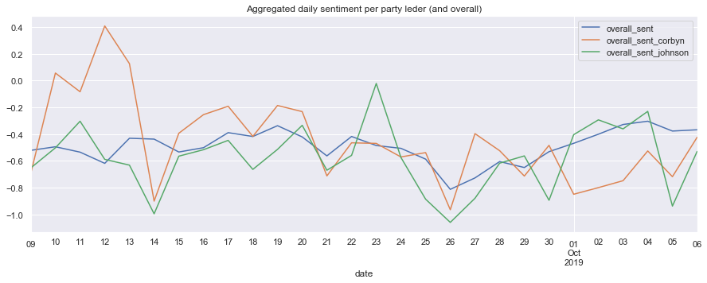

```python
evaluation[['overall_sent', 'overall_sent_corbyn', 'overall_sent_johnson']].plot(title='Aggregated daily sentiment per party leder (and overall)') # plot
```

RQ1 asked how the evaluation of Jeremy Corbyn's Brexit strategy develops over time. RQ2 asked what effects the two party conferences had on this development.

Clearly, the chosen measurement suggest that the labour party conference was not successful in improving the evaluation of Jeremy Corbyns Brexit strategy, which necessitates a review of what went wrong and how the party might be able to improve their public appearence during their next party conference.

Given that the party conference was not successful in improving Jeremy Corbyn's evaluation, let's turn to H2 in order to see whether he himself was able to steer public discourse in a more favourable way:

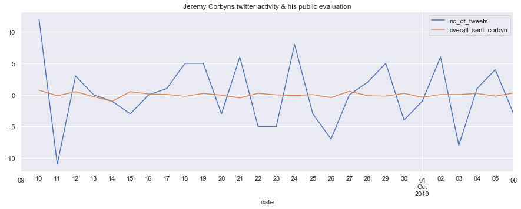

```python
ts_data[['no_of_tweets', 'overall_sent_corbyn']].plot(title='Jeremy Corbyns twitter activity & his public evaluation') # plot
```

As can be seen in this visualisation as well as in the results of the time series analysis, Jeremy Corbyn's tweet frequency had no significant effect on his evaluation on Twitter. While the frequency didn't matter, it might still be that the content did. However, this was not accounted for in this analysis.

Overall, it has to be concluded that Jeremy Corbyn's Brexit strategy was evaluated worse over time by the public on Twitter and that neither the party conference, nor his own official twitter activity was able to turn this trend around. This suggests that Jeremy Corbyn should overthink either his Brexit-position, which, as noted earlier, is rather ambiguous (Edgington, 2019), or his and his party's online communication of it.

H3 aimed at finding some meaningful suggestions for how Jeremy Corbyn might improve his tweets to gain additional reach (retweets). However, the hypothesised elements of a tweet, namely emotionality and sentiment, dd nt have a significant effect on retweets in the overall dataset. This means that other features, possibly length, topic, or specfic hashtags might be more helpful. However, future analyses will be needed in order to test whether these elements actually do have an effect.

## Limitations and Next Steps

While analysing the Twitter discourse around Jeremy Corbyn has the advantage of being a cost-effective measure of manifest behaviour, it doesn't come without limitations. On a general level, it is important to note that a bigger dataset in and of itself doesn't make the results more meaningful (Boyd & Crawford, 2012). For example, the current analysis relied on a large dataset of tweets that contained the word "Brexit" and/or one or both of two associated hashtags (#Remainers, #Brexitiers). While this sample naturally encompasses various tweets that refer to Jeremy Corbyn's Brexit strategy, it might have been too broad. That is, because it can't necessarily be expected that every tweet that mentions Jeremy Corbyn also presents an overall evaluation of him. In fact, some of the most common hashtags (e.g. #leaveoct31) point to this being the case.  
Similarly, the sentiment analysis develloped by Thelwall, et al.(2010) only distinguished between positive, negative and neutral words. This does not take into account nuances in how positive or negative a word might be, nor does it pay attention to the specific context in which some words might take on different meanings.

As for the data-preparation, it has to be noted that no distinction was made between tweets that mentioned only Jeremy Corbyn and tweets that mentioned him together with prime minister Boris Johnson. While the latter ategory only made for 10% of the total sample, the fact that those tweets were more negative on average might still have skewed the later analysis. Furthermore, the assumption that a tweet that mentions not only Jeremy Corbyn but also Boris Johnson still constitutes an evaluation of the former might in fact be a little too far fetched.

The abovementioned limitations might somewhat call into question the value of the results gained in the analysis. As for the ANOVA, it is also worth pointing out that a) the time periods post-LC and pre-CC were overlapping, b) the four-day period was chosen rather arbitrarily, and c) it doesn't take into account other events that happened at the time. Regarding the ANOVA-results, especially limitations a) and c) are concerning. That is, because the time period after the labour party conference was rather short and with the tory party conference coming up, positive effects from it might not have lasted for four full days. Furthermore, events such as the supreme court ruling that the suspension of parliament was unlawful on the 24th of September, as well as personal scandals of Boris Johnson might have affected the Twitter discourse around Brexit in ways that this analysis does not account for. In other words, full causality can not be deduced from the findings of the two ANOVAs as other confoundig variables might have caused the differences.  
Another aspect concerning the hypothesis testing that is noteworthy, is that the time series analysis was performed with only one lag. While it can be assumed that Jeremy Corbyn's daily tweet-frequency does not have long-lasting effects on sentiment, limiting the lags to just one from the very beginning might still be a little too much. Then again, no meaningful effects of one variable on the other were found, so having more lags might not necessarily make sense.  
Lastly, regarding H3, it needs to be noted that analysing the effect that emotionality and sentiment had on retweets in the whole sample might be problematic insofar, as th popularity of different accounts could have confounded possible effects. Hence, the analysis should be repeated for Jeremy Corbyn's personal set of tweets.

### Next steps

The current analysis would profit from both, methodological improvements and differentiated follow-up studies. As for improvements, it would be worth comparing different sentiment analysis tools, to evaluate which one fits the context best and is able to provide most nuance. Thereby, the sentiment analysis could move beyond its currently rather crude measurement. Similarly, it would be worthwhile to re-do the ANOVAs with different (probably shorter) time frames to avoid overlapping effects. Moreover, to gain a better understanding of what is happening, it might be necessary to consider more important events than just the two party conferences, or, alternatively, zoom in on for example Jeremy Corbyn's speech and test for direct effects that this had.

From an academic standpoint, it would also be interesting to repeat the analysis with "emotionality" as the dependent variable, since, unlike with sentiment, polarisation does not hide its variation.

The most important question of course is, how the labour party can profit from this analysis. First of all, survey and focus group data might help to evaluate the labour party conference, which clearly did not have the expected effects (unlike the conservative party conference).  
Another interesting notion is, that Twitter is more useful for discrediting opponents than it is for gaining support and positive feedback of ones' own policies. The fact that the conservative party conference had the expected negative effect on Jeremy Corbyn's evaluation points in this direction. Naturally, this claim would need to be tested by seeing whether the labour party conference had a negative effect on Boris Johnson's sentiment, but if it would prove to be true, this insight might help Jeremy Corbyn and his advisors to use Twitter more effectively. It might also be worth to consider using sentiment topic recognition (STR) in order to find the most representative topics discussed for each sentiment, as suggested by Mostafa (2013). This might help provide more detailled insights into what Twitter users are most concerend with. Furthermore, as noted earlier, future analysis could investigate which features of a tweet improve its reach. This way, Jeremy Corbyn could at least ensure that he reaches more people on Twitter.

## Ethical, Privacy and Normative Considerations

Gathering data for Twitter analyses is comparably easy and cost-efficient. However, an aspect that is often forgotten are ethical considerations, which receive a lot more attention in traditional academic methods such as experiments (Boyd & Craword, 2012). When it comes to this analysis, several potential ethical and privacy issues come to mind.

First of all, it is noteworthy that there is an important difference between "being in public (i.e. sitting in a park) and being public (i.e. actively courting attention)" (Boyd & Marwick 2011, as cited in Boyd & Crawford, 2012). Applied to Twitter, this analogy means that while tweets are public by default and most Twitter users can be expected to be aware of that, this fact in itself doesn't mean that those users like the idea of having their tweets analysed. More importantly, there is no way for those users to know that their content is being analysed (although in an anonymised and aggregated form), nor do they have an opportunity to have their tweets removed from the dataset. The latter issue does not only seem unfair, but actually contradicts with the right to be forgotten.

Another issue is the amount of data that was collected in the first place. According to GDPR rules, one is only allowed to collect data when there is a plan on how to use it. With this dataset, this was not the case as many variables in the original dataset were not used in the analysis. While the GDPR moght not apply to Twitter data, this issue nonetheless goes against what one might describe as good practice.

That said, compared to commercial data usage by various companies, this analysis is rather harmless. That is, because the data was gathered from Jeremy Corbyn's public account, as well as from anaonymised Twitter users. However, as soon as the labour party would try to gather more personal data from external data brokers (data that must surely be available as Twitter users might be tracked beyond just Twitter), it would run the risk of invading users privacy and contributing to a questionable business model in which data brokers operate largely in the dark and face little regulatory oversight (Martin, 2015).

## References

- Borra, E., & Rieder, B. (2014). Programmed method: developing a toolset for capturing and analyzing tweets. *Aslib Journal of Information Management, 66*(3), 262-278.
- Boyd, D., & Crawford, K. (2012). Critical questions for big data: Provocations for a cultural, technological, and scholarly phenomenon. *Information, communication & society, 15*(5), 662-679.
- Conway, B. A., Kenski, K., & Wang, D. (2015). The rise of Twitter in the political campaign: Searching for intermedia agenda-setting effects in the presidential primary. *Journal of Computer-Mediated Communication, 20*(4), 363-380.
- Cobb, R., Ross, J. K., & Ross, M. H. (1976). Agenda building as a comparative political process. *American political science review, 70*(1), 126-138.
- Edgington, T (Sep. 23rd 2019). What is Labour's Brexit plan? *Bbc Reality Check*. Retrieved Oct 2nd from: https://www.bbc.com/news/uk-politics-45640548
- Martin, K. E. (2015). Ethical issues in the big data industry. *MIS Quarterly Executive, 14*(2).
- Mueller, B (Sep 23rd 2019). Boris Johnson Faces a New Scandal, and ‘People See Blood in the Water’. *The New York Times*. Retrieved Oct. 20th from: https://www.nytimes.com/2019/09/23/world/europe/boris-johnson-jennifer-arcuri.html
- Mostafa, M. M. (2013). More than words: Social networks’ text mining for consumer brand sentiments. *Expert Systems with Applications, 40*(10), 4241-4251.
- Pasek, J., & Krosnick, J. A. (2010). Optimizing survey questionnaire design in political science: Insights from psychology. *Oxford handbook of American elections and political behavior*, 27-50.
- Politico (n.d.). *United Kingdom — National parliament voting intention*. Retrieved on Sep 29th from: https://www.politico.eu/europe-poll-of-polls/united-kingdom/
- Russell Neuman, W., Guggenheim, L., Mo Jang, S., & Bae, S. Y. (2014). The dynamics of public attention: Agenda-setting theory meets big data. *Journal of Communication, 64*(2), 193-214.
- Skogerbø, E., & Krumsvik, A. H. (2015). Newspapers, Facebook and Twitter: Intermedial agenda setting in local election campaigns. *Journalism Practice, 9*(3), 350-366.
- Thelwall, M., Buckley, K., Paltoglou, G., Cai, D., & Kappas, A. (2010). Sentiment strength detection in short informal text. *Journal of the American Society for Information Science and Technology, 61*(12), 2544-2558.